# Intro To GGPlot2

GGPlot2 is one of the coolest features that R offers. After all, visualization could offer some of the most versatile way of analyzing data. It is a very advanced way of of graphing and plotting that gives users a very advanced way of graphing various plots. There are a few very basic arguments that GGPlot2 that allows for most basic graphing features. To practice graphing with GGPlot2, we will be using the practice data set, mtcars. First, you may need to make sure you download GGPlot2.

```r
install.packages(ggplot2)
library('ggplot2')
library(gridExtra)
```

## Main Arguments

ggplot2 has several important arguments that gives RStudio numerous foundational arguments that provides most basic graphing functionalities.

### Data

Before, you can get into graphing data, it's important to be able to analyze and potentially clean data to be able work with it on GGPlot2. mtcars and diamonds will be the example data sets that we can use to learn about ggplot2. This WorkBook will show the basics of GGPlot arguments with Mtcars and some cool graphs with diamonds.

```r
# How to reference data with ggplot
# ggplot(data, remainder of your arguments)
mtcars
```

|  | mpg | cyl | disp | hp | drat | wt | qsec | vs | am | gear | carb |
| --- | --- | --- | --- | --- | --- | --- | --- | --- | --- | --- | --- |
| Mazda RX4 | 21.0 | 6 | 160.0 | 110 | 3.90 | 2.620 | 16.46 | 0 | 1 | 4 | 4 |
| Mazda RX4 Wag | 21.0 | 6 | 160.0 | 110 | 3.90 | 2.875 | 17.02 | 0 | 1 | 4 | 4 |
| Datsun 710 | 22.8 | 4 | 108.0 | 93 | 3.85 | 2.320 | 18.61 | 1 | 1 | 4 | 1 |
| Hornet 4 Drive | 21.4 | 6 | 258.0 | 110 | 3.08 | 3.215 | 19.44 | 1 | 0 | 3 | 1 |
| Hornet Sportabout | 18.7 | 8 | 360.0 | 175 | 3.15 | 3.440 | 17.02 | 0 | 0 | 3 | 2 |
| Valiant | 18.1 | 6 | 225.0 | 105 | 2.76 | 3.460 | 20.22 | 1 | 0 | 3 | 1 |
| Duster 360 | 14.3 | 8 | 360.0 | 245 | 3.21 | 3.570 | 15.84 | 0 | 0 | 3 | 4 |
| Merc 240D | 24.4 | 4 | 146.7 | 62 | 3.69 | 3.190 | 20.00 | 1 | 0 | 4 | 2 |
| Merc 230 | 22.8 | 4 | 140.8 | 95 | 3.92 | 3.150 | 22.90 | 1 | 0 | 4 | 2 |
| Merc 280 | 19.2 | 6 | 167.6 | 123 | 3.92 | 3.440 | 18.30 | 1 | 0 | 4 | 4 |
| Merc 280C | 17.8 | 6 | 167.6 | 123 | 3.92 | 3.440 | 18.90 | 1 | 0 | 4 | 4 |
| Merc 450SE | 16.4 | 8 | 275.8 | 180 | 3.07 | 4.070 | 17.40 | 0 | 0 | 3 | 3 |
| Merc 450SL | 17.3 | 8 | 275.8 | 180 | 3.07 | 3.730 | 17.60 | 0 | 0 | 3 | 3 |
| Merc 450SLC | 15.2 | 8 | 275.8 | 180 | 3.07 | 3.780 | 18.00 | 0 | 0 | 3 | 3 |
| Cadillac Fleetwood | 10.4 | 8 | 472.0 | 205 | 2.93 | 5.250 | 17.98 | 0 | 0 | 3 | 4 |
| Lincoln Continental | 10.4 | 8 | 460.0 | 215 | 3.00 | 5.424 | 17.82 | 0 | 0 | 3 | 4 |
| Chrysler Imperial | 14.7 | 8 | 440.0 | 230 | 3.23 | 5.345 | 17.42 | 0 | 0 | 3 | 4 |
| Fiat 128 | 32.4 | 4 | 78.7 | 66 | 4.08 | 2.200 | 19.47 | 1 | 1 | 4 | 1 |
| Honda Civic | 30.4 | 4 | 75.7 | 52 | 4.93 | 1.615 | 18.52 | 1 | 1 | 4 | 2 |
| Toyota Corolla | 33.9 | 4 | 71.1 | 65 | 4.22 | 1.835 | 19.90 | 1 | 1 | 4 | 1 |
| Toyota Corona | 21.5 | 4 | 120.1 | 97 | 3.70 | 2.465 | 20.01 | 1 | 0 | 3 | 1 |
| Dodge Challenger | 15.5 | 8 | 318.0 | 150 | 2.76 | 3.520 | 16.87 | 0 | 0 | 3 | 2 |
| AMC Javelin | 15.2 | 8 | 304.0 | 150 | 3.15 | 3.435 | 17.30 | 0 | 0 | 3 | 2 |
| Camaro Z28 | 13.3 | 8 | 350.0 | 245 | 3.73 | 3.840 | 15.41 | 0 | 0 | 3 | 4 |
| Pontiac Firebird | 19.2 | 8 | 400.0 | 175 | 3.08 | 3.845 | 17.05 | 0 | 0 | 3 | 2 |
| Fiat X1-9 | 27.3 | 4 | 79.0 | 66 | 4.08 | 1.935 | 18.90 | 1 | 1 | 4 | 1 |
| Porsche 914-2 | 26.0 | 4 | 120.3 | 91 | 4.43 | 2.140 | 16.70 | 0 | 1 | 5 | 2 |
| Lotus Europa | 30.4 | 4 | 95.1 | 113 | 3.77 | 1.513 | 16.90 | 1 | 1 | 5 | 2 |
| Ford Pantera L | 15.8 | 8 | 351.0 | 264 | 4.22 | 3.170 | 14.50 | 0 | 1 | 5 | 4 |
| Ferrari Dino | 19.7 | 6 | 145.0 | 175 | 3.62 | 2.770 | 15.50 | 0 | 1 | 5 | 6 |
| Maserati Bora | 15.0 | 8 | 301.0 | 335 | 3.54 | 3.570 | 14.60 | 0 | 1 | 5 | 8 |
| Volvo 142E | 21.4 | 4 | 121.0 | 109 | 4.11 | 2.780 | 18.60 | 1 | 1 | 4 | 2 |

[output not shown]

```r
diamonds
```

| carat | cut | color | clarity | depth | table | price | x | y | z |
| --- | --- | --- | --- | --- | --- | --- | --- | --- | --- |
| 0.23 | Ideal | E | SI2 | 61.5 | 55 | 326 | 3.95 | 3.98 | 2.43 |
| 0.21 | Premium | E | SI1 | 59.8 | 61 | 326 | 3.89 | 3.84 | 2.31 |
| 0.23 | Good | E | VS1 | 56.9 | 65 | 327 | 4.05 | 4.07 | 2.31 |
| 0.29 | Premium | I | VS2 | 62.4 | 58 | 334 | 4.20 | 4.23 | 2.63 |
| 0.31 | Good | J | SI2 | 63.3 | 58 | 335 | 4.34 | 4.35 | 2.75 |
| 0.24 | Very Good | J | VVS2 | 62.8 | 57 | 336 | 3.94 | 3.96 | 2.48 |
| 0.24 | Very Good | I | VVS1 | 62.3 | 57 | 336 | 3.95 | 3.98 | 2.47 |
| 0.26 | Very Good | H | SI1 | 61.9 | 55 | 337 | 4.07 | 4.11 | 2.53 |
| 0.22 | Fair | E | VS2 | 65.1 | 61 | 337 | 3.87 | 3.78 | 2.49 |
| 0.23 | Very Good | H | VS1 | 59.4 | 61 | 338 | 4.00 | 4.05 | 2.39 |
| 0.30 | Good | J | SI1 | 64.0 | 55 | 339 | 4.25 | 4.28 | 2.73 |
| 0.23 | Ideal | J | VS1 | 62.8 | 56 | 340 | 3.93 | 3.90 | 2.46 |
| 0.22 | Premium | F | SI1 | 60.4 | 61 | 342 | 3.88 | 3.84 | 2.33 |
| 0.31 | Ideal | J | SI2 | 62.2 | 54 | 344 | 4.35 | 4.37 | 2.71 |
| 0.20 | Premium | E | SI2 | 60.2 | 62 | 345 | 3.79 | 3.75 | 2.27 |
| 0.32 | Premium | E | I1 | 60.9 | 58 | 345 | 4.38 | 4.42 | 2.68 |
| 0.30 | Ideal | I | SI2 | 62.0 | 54 | 348 | 4.31 | 4.34 | 2.68 |
| 0.30 | Good | J | SI1 | 63.4 | 54 | 351 | 4.23 | 4.29 | 2.70 |
| 0.30 | Good | J | SI1 | 63.8 | 56 | 351 | 4.23 | 4.26 | 2.71 |
| 0.30 | Very Good | J | SI1 | 62.7 | 59 | 351 | 4.21 | 4.27 | 2.66 |
| 0.30 | Good | I | SI2 | 63.3 | 56 | 351 | 4.26 | 4.30 | 2.71 |
| 0.23 | Very Good | E | VS2 | 63.8 | 55 | 352 | 3.85 | 3.92 | 2.48 |
| 0.23 | Very Good | H | VS1 | 61.0 | 57 | 353 | 3.94 | 3.96 | 2.41 |
| 0.31 | Very Good | J | SI1 | 59.4 | 62 | 353 | 4.39 | 4.43 | 2.62 |
| 0.31 | Very Good | J | SI1 | 58.1 | 62 | 353 | 4.44 | 4.47 | 2.59 |
| 0.23 | Very Good | G | VVS2 | 60.4 | 58 | 354 | 3.97 | 4.01 | 2.41 |
| 0.24 | Premium | I | VS1 | 62.5 | 57 | 355 | 3.97 | 3.94 | 2.47 |
| 0.30 | Very Good | J | VS2 | 62.2 | 57 | 357 | 4.28 | 4.30 | 2.67 |
| 0.23 | Very Good | D | VS2 | 60.5 | 61 | 357 | 3.96 | 3.97 | 2.40 |
| 0.23 | Very Good | F | VS1 | 60.9 | 57 | 357 | 3.96 | 3.99 | 2.42 |
| ⋮ | ⋮ | ⋮ | ⋮ | ⋮ | ⋮ | ⋮ | ⋮ | ⋮ | ⋮ |
| 0.70 | Premium | E | SI1 | 60.5 | 58 | 2753 | 5.74 | 5.77 | 3.48 |
| 0.57 | Premium | E | IF | 59.8 | 60 | 2753 | 5.43 | 5.38 | 3.23 |
| 0.61 | Premium | F | VVS1 | 61.8 | 59 | 2753 | 5.48 | 5.40 | 3.36 |
| 0.80 | Good | G | VS2 | 64.2 | 58 | 2753 | 5.84 | 5.81 | 3.74 |
| 0.84 | Good | I | VS1 | 63.7 | 59 | 2753 | 5.94 | 5.90 | 3.77 |
| 0.77 | Ideal | E | SI2 | 62.1 | 56 | 2753 | 5.84 | 5.86 | 3.63 |
| 0.74 | Good | D | SI1 | 63.1 | 59 | 2753 | 5.71 | 5.74 | 3.61 |
| 0.90 | Very Good | J | SI1 | 63.2 | 60 | 2753 | 6.12 | 6.09 | 3.86 |
| 0.76 | Premium | I | VS1 | 59.3 | 62 | 2753 | 5.93 | 5.85 | 3.49 |
| 0.76 | Ideal | I | VVS1 | 62.2 | 55 | 2753 | 5.89 | 5.87 | 3.66 |
| 0.70 | Very Good | E | VS2 | 62.4 | 60 | 2755 | 5.57 | 5.61 | 3.49 |
| 0.70 | Very Good | E | VS2 | 62.8 | 60 | 2755 | 5.59 | 5.65 | 3.53 |
| 0.70 | Very Good | D | VS1 | 63.1 | 59 | 2755 | 5.67 | 5.58 | 3.55 |
| 0.73 | Ideal | I | VS2 | 61.3 | 56 | 2756 | 5.80 | 5.84 | 3.57 |
| 0.73 | Ideal | I | VS2 | 61.6 | 55 | 2756 | 5.82 | 5.84 | 3.59 |
| 0.79 | Ideal | I | SI1 | 61.6 | 56 | 2756 | 5.95 | 5.97 | 3.67 |
| 0.71 | Ideal | E | SI1 | 61.9 | 56 | 2756 | 5.71 | 5.73 | 3.54 |
| 0.79 | Good | F | SI1 | 58.1 | 59 | 2756 | 6.06 | 6.13 | 3.54 |
| 0.79 | Premium | E | SI2 | 61.4 | 58 | 2756 | 6.03 | 5.96 | 3.68 |
| 0.71 | Ideal | G | VS1 | 61.4 | 56 | 2756 | 5.76 | 5.73 | 3.53 |
| 0.71 | Premium | E | SI1 | 60.5 | 55 | 2756 | 5.79 | 5.74 | 3.49 |
| 0.71 | Premium | F | SI1 | 59.8 | 62 | 2756 | 5.74 | 5.73 | 3.43 |
| 0.70 | Very Good | E | VS2 | 60.5 | 59 | 2757 | 5.71 | 5.76 | 3.47 |
| 0.70 | Very Good | E | VS2 | 61.2 | 59 | 2757 | 5.69 | 5.72 | 3.49 |
| 0.72 | Premium | D | SI1 | 62.7 | 59 | 2757 | 5.69 | 5.73 | 3.58 |
| 0.72 | Ideal | D | SI1 | 60.8 | 57 | 2757 | 5.75 | 5.76 | 3.50 |
| 0.72 | Good | D | SI1 | 63.1 | 55 | 2757 | 5.69 | 5.75 | 3.61 |
| 0.70 | Very Good | D | SI1 | 62.8 | 60 | 2757 | 5.66 | 5.68 | 3.56 |
| 0.86 | Premium | H | SI2 | 61.0 | 58 | 2757 | 6.15 | 6.12 | 3.74 |
| 0.75 | Ideal | D | SI2 | 62.2 | 55 | 2757 | 5.83 | 5.87 | 3.64 |

#### subsets

This is a useful way to further compartmentalize data within a set to further analyze. This would be treated exactly the same as the data arguments in ggplot, but gives users the ability to focus on a specific set of data.

### aes()

aes() or aesthetic mapping is one of the arguments that can truly never be ignored. This argument deals with the structure of data visualization on a graph. There are several ways to mess around with aes to improve any visualization one is working with.

#### axises

aes can be used to assign axises in a data set.

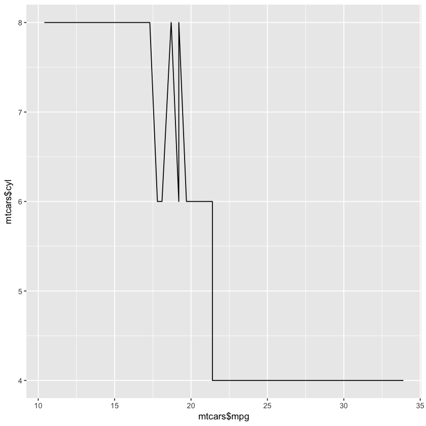

```r
# Axises
ggplot(mtcars, aes(x = mtcars$mpg, y = mtcars$cyl)) + geom_line()
```

#### color

This is a very simple argument that can add another level to any visualization

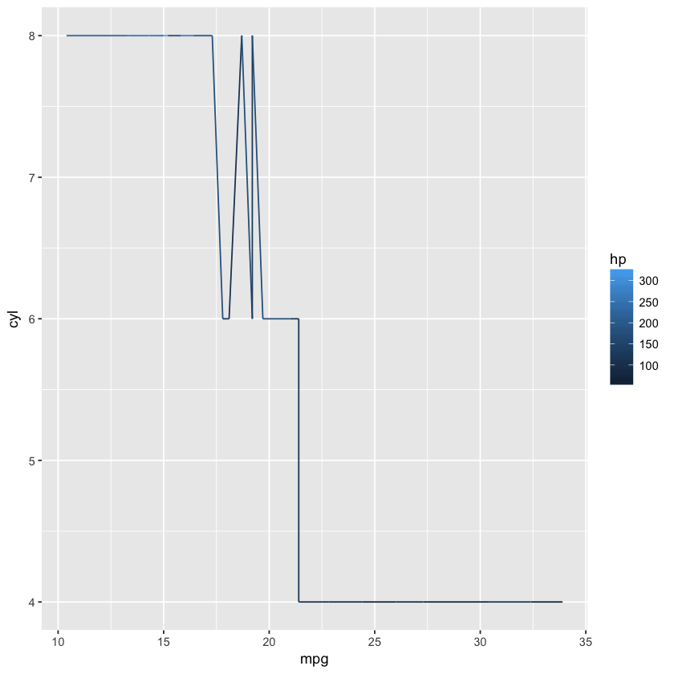

```r
# Assigning Color in GGPlot2 to another value
ggplot(mtcars, aes(x = mpg, y = cyl, color = hp)) + geom_line()
```

We will discuss picking colors as that will come up in the other major argument of ggplot2, geom.

### geom

geom underscore one of various different options, such as point, line, boxplot, etc. gives the user much more control over how the individual data points are represented within a specific data set.

#### Arguments within geom

##### color

As you may have noticed during aes that when you assign a color, it uses a default. But, what if you wanted to use your own color scheme. Well it's a very simple argument within geom.

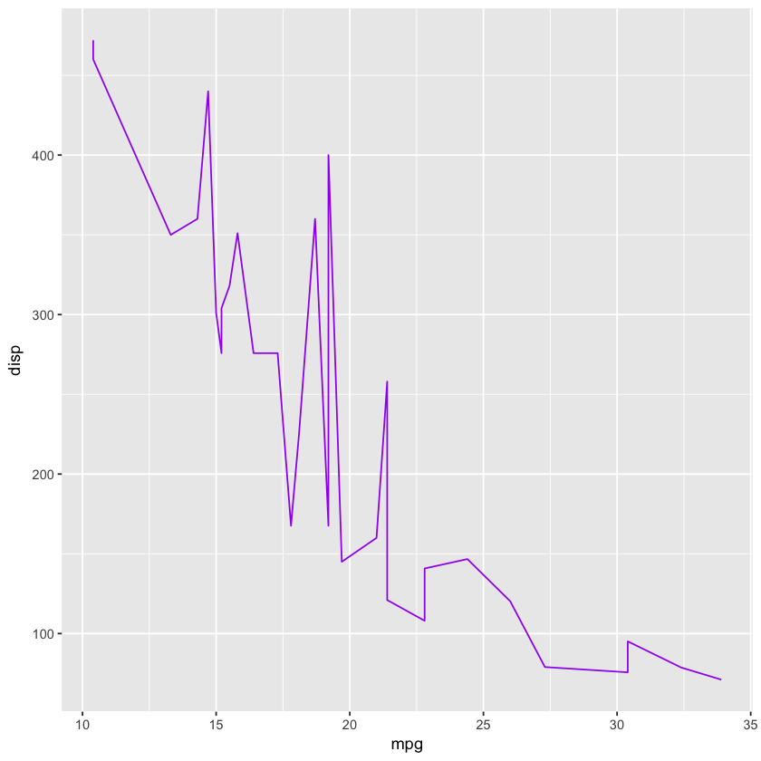

```r
# Assigning Color in GGPlot2 to another value
ggplot(mtcars, aes(x = mpg, y = disp)) + geom_line(color = "purple")
```

##### shape within geom

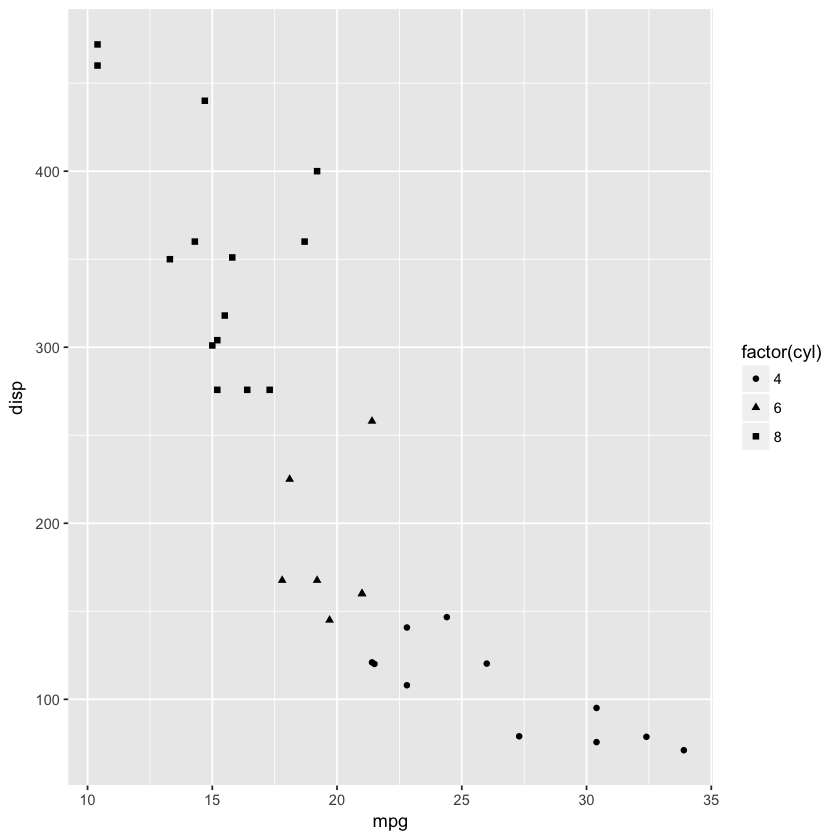

```r
ggplot(mtcars, aes(x = mpg, y = disp)) + geom_point(aes(shape = factor(cyl)))
```

##### size of points within geom

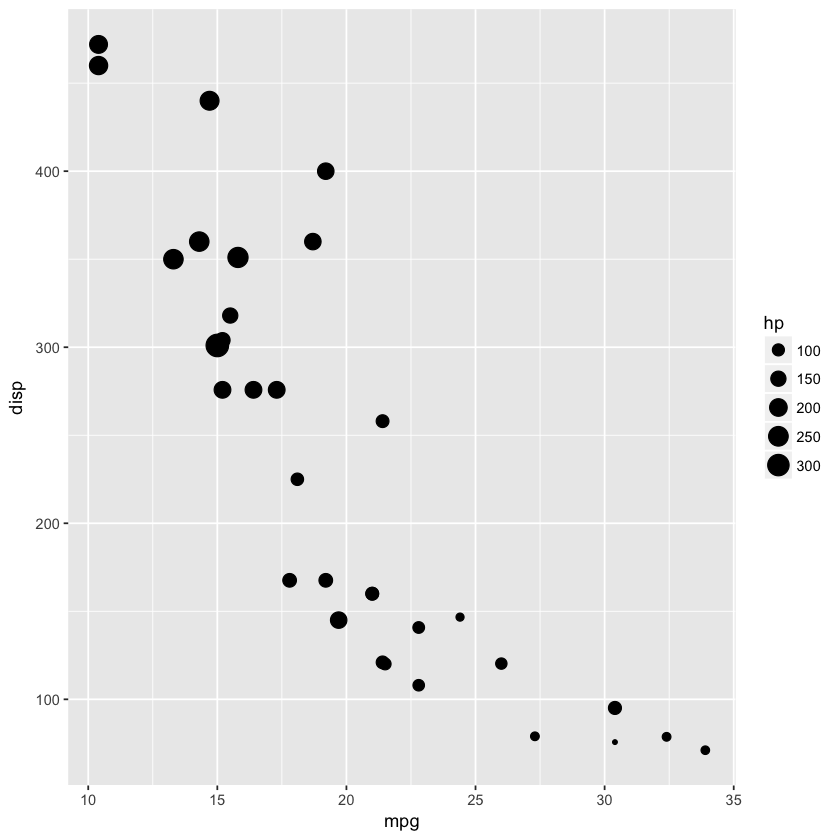

```r
ggplot(mtcars, aes(x = mpg, y = disp)) + geom_point(aes(size = hp))
```

##### alpha within geom

This final geom feature is more obscure then the others listed above. The alpha argument is simply a way of using fading as a way to demonstrate the prevalence of specific values, alpha can be a very useful feature from geom_point.

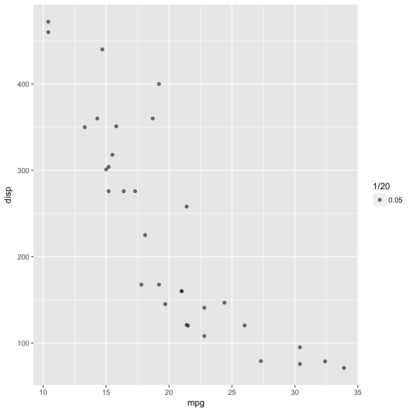

```r
ggplot(mtcars, aes(x = mpg, y = disp)) + geom_point(aes(alpha = 1/20))
```

#### geom_line

These can be used for several types of graphs, such as time series (a common one in bioinformatics), trend lines (very useful in economics), and several other line graph applications.

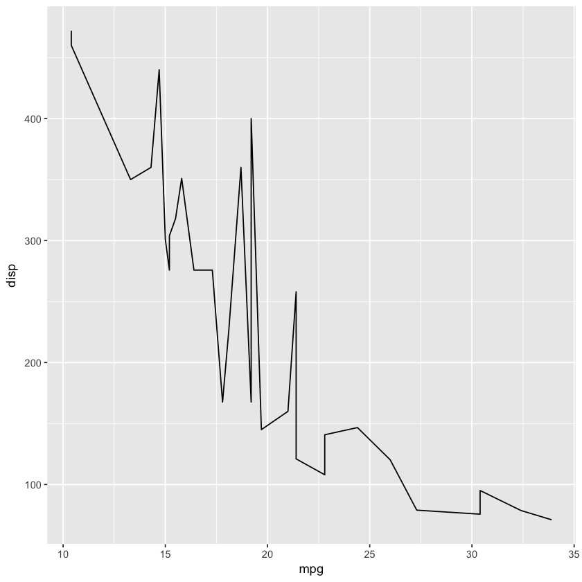

```r
ggplot(mtcars, aes(x = mpg, y = disp)) + geom_line()
```

#### geom_point

Geom Point is the other extremely commonly used to look at individual data points. These are used for several common graphical representations such as scatterplots, dot plots etc. One of the biggest applications for this is found in the above sections as you can apply features such as size, shape, and/or color to any visualization.

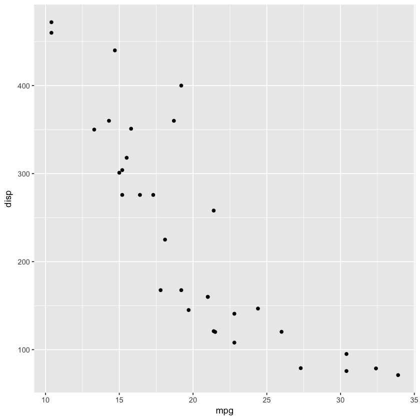

```r
ggplot(mtcars, aes(x = mpg, y = disp)) + geom_point()
```

#### geom_boxplot

Boxplots are also another very simple applicaiton of ggplot2.

```r
ggplot(mtcars, aes(x = factor(cyl), y = mpg)) + geom_boxplot()
```

[output not shown]

### geom_smooth

Finally, geom_smooth is an additional R feature that applies some of the statistics skills you learn in this class to find something similar to error bars on a line graph, giving you a range within confidence.

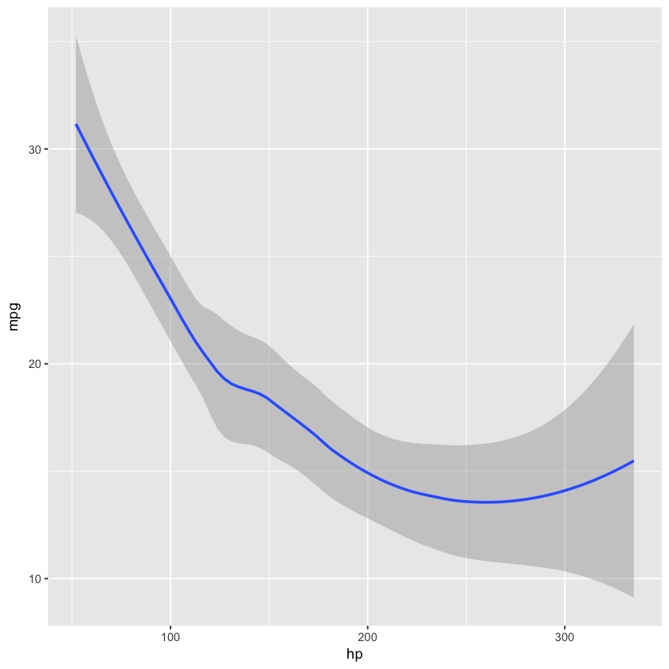

```r
ggplot(mtcars, aes(x = hp, y = mpg)) + geom_smooth()
```

#### All the other geom arguments

Listed above are just some of the common that are most commonly used in ggplot2. However, if you want to learn even more cool features available through geom, run the following and this will layout all the various options available.

```r
help.search("geom_", package = "ggplot2")
```

### facets

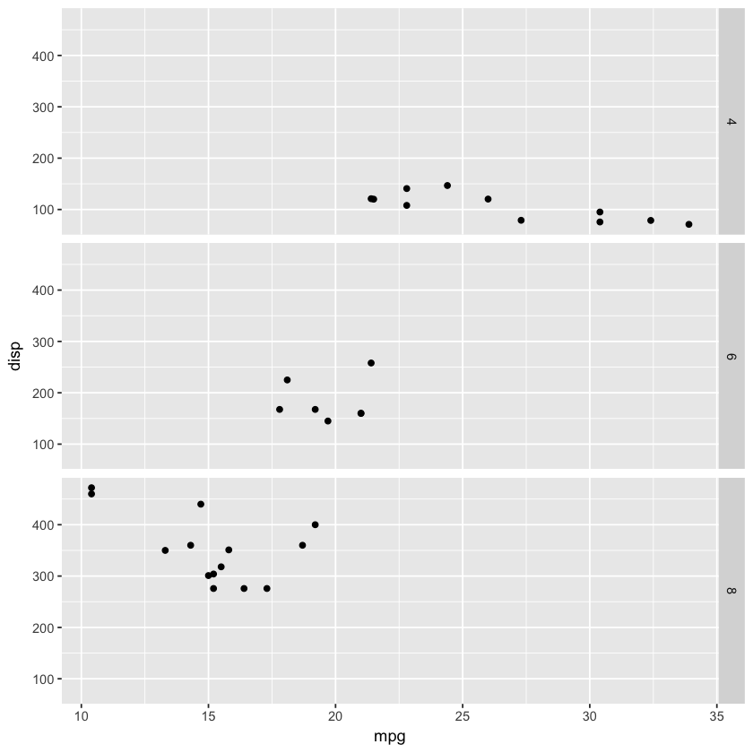

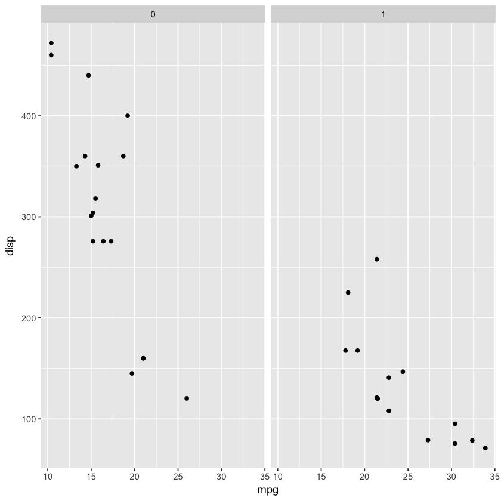

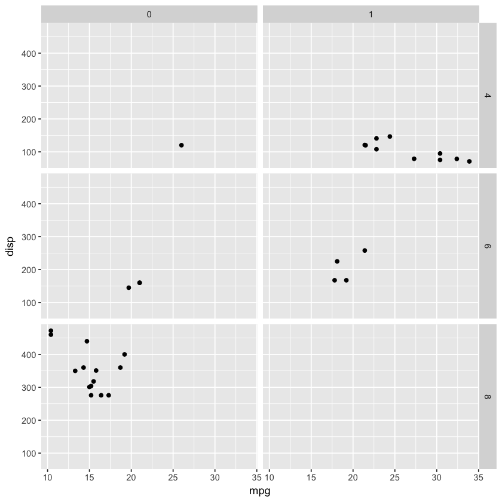

```r
# Facets
ggplot(mtcars, aes(x = mpg, y = disp)) + geom_point() + facet_grid(cyl~.)
ggplot(mtcars, aes(x = mpg, y = disp)) + geom_point() + facet_grid(.~vs)
ggplot(mtcars, aes(x = mpg, y = disp)) + geom_point() + facet_grid(cyl~vs)
```

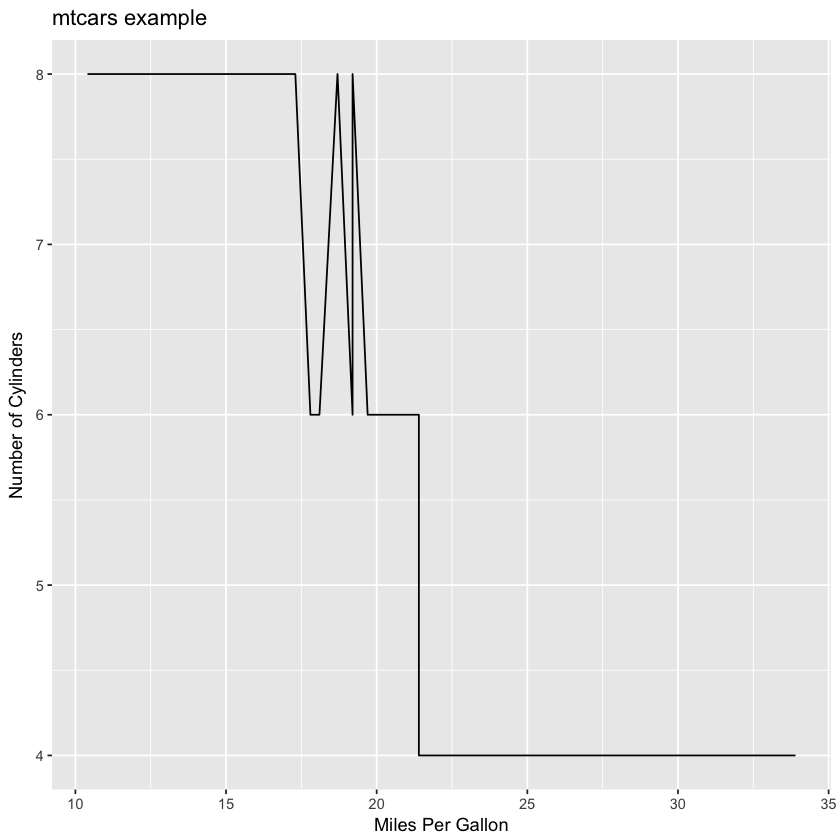

```r
# Axis Titles
ggplot(mtcars, aes(x = mtcars$mpg, y = mtcars$cyl)) + labs(title = "mtcars example", x = "Miles Per Gallon", y = "Number of Cylinders") + geom_line()
```

### Histograms

This is perhaps the simplest graphing functionality offered through R. It can be used for a very basic overview of a column in a dataframe.

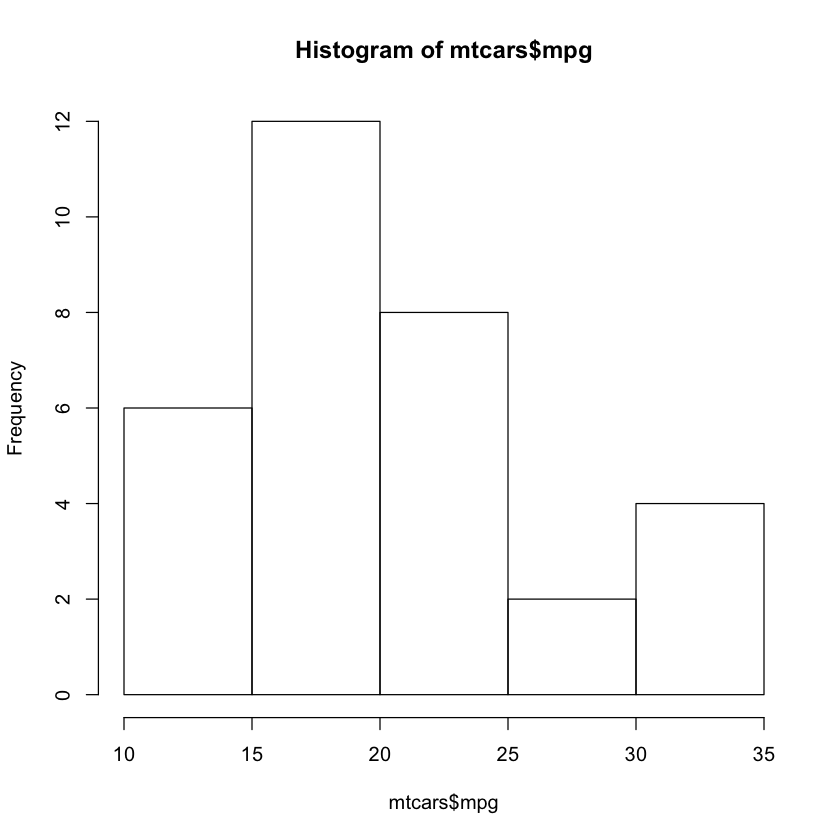

```r
hist(mtcars$mpg)
```

### ggplot2 histograms (geom_histogram)

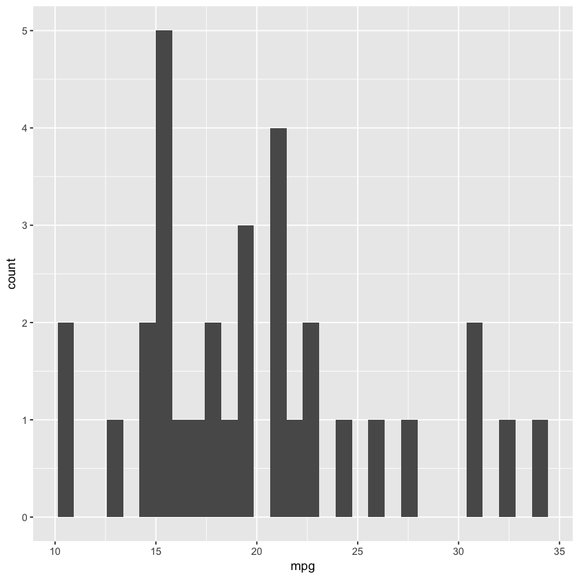

```r
ggplot(mtcars, aes(x = mpg)) + geom_histogram()
```

## Examples of Graphing in R

While everything explained above breaks down all of the necessary GGPlot arguments to be familiar with to be successful, it would probably be good to dive into the various graphs you can make with GGPlot. This is where we will be taking advantage of the Diamonds Data Set to make some straightforward graphs using the ideas.

### Stacking Bar Graphs

The Key to making stacked bar graphs deals with the fill argument with aes().

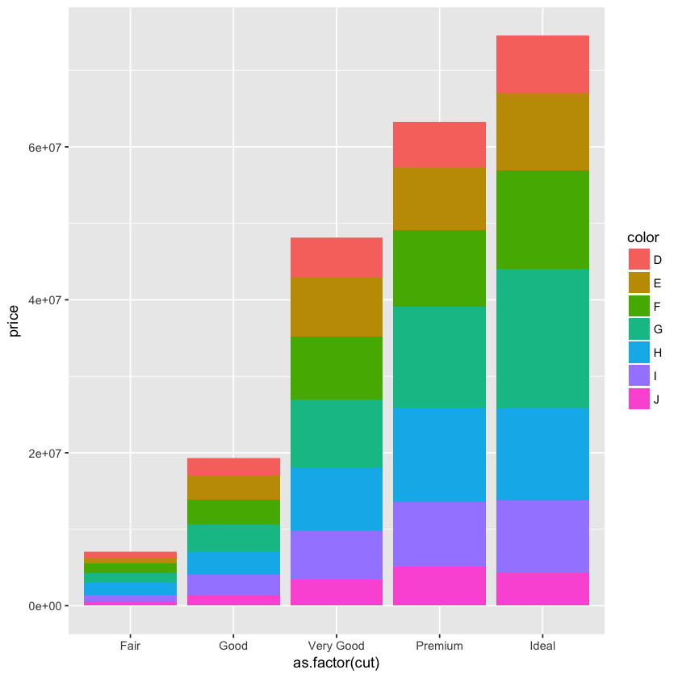

```r
# The following code applies the geom_bar arguments to make stacked bar graphs.
ggplot(diamonds, aes(x =as.factor(cut), y=price, fill = color)) + geom_bar(stat="identity")
```

### Adding Names to Data Points

What if you were working with a dataset where you want to see what a specific dataset were to correspond with a specific name. For instance you want to put the clarity. For this example, I am actually going to use mtcars.

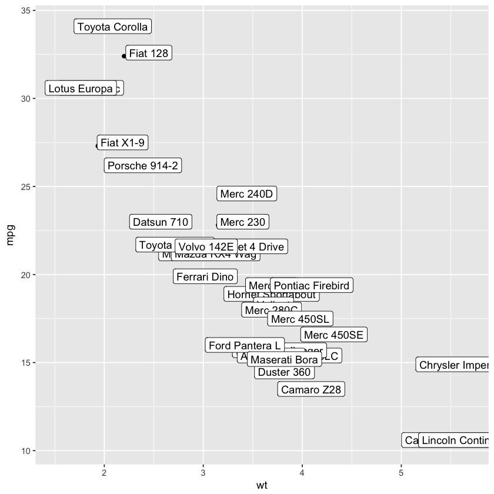

```r
# The key is the nudge argument
ggplot(mtcars, aes(x=wt, y=mpg)) +
  geom_point() +
  geom_label(label=rownames(mtcars), nudge_x = 0.25, nudge_y = 0.2)
```

### Multiple Graphs in One Figure

```r
install.packages(gridExtra)
library(gridExtra)

# Show the 4 plots on the same page
grid.arrange(g1, g2, g3, ncol=1, nrow =3)

# Plots
grid.arrange(g2, arrangeGrob(g3, g1, ncol=2), nrow = 2)
grid.arrange(g1, g2, g3, nrow = 3)
```

[output not shown]

[output not shown]

Sources: http://had.co.nz/stat480/lectures/07-r-intro.pdf https://stackoverflow.com/questions/39679057/r-ggplot2-stat-count-must-not-be-used-with-a-y-aesthetic-error-in-bar-graph http://ggplot2.tidyverse.org/reference/labs.html http://www.sthda.com/english/wiki/ggplot2-colors-how-to-change-colors-automatically-and-manually http://ggplot2.tidyverse.org/reference/geom_point.html https://plot.ly/ggplot2/geom_density/ Harvard: http://tutorials.iq.harvard.edu/R/Rgraphics/Rgraphics.html http://www.r-graph-gallery.com/275-add-text-labels-with-ggplot2/